# Actividad 2.9 Regresión Logistica Multiple

Lucero Díaz

2026-10-11

#### a. Carga los datos y las librerías

```r
# Load dataset
data(mtcars)

# Convert 'am' to factor (0 = auto, 1 = manual)
mtcars$am <- factor(mtcars$am, labels = c("Automatic", "Manual"))
```

#### b. Explora los datos

```r
# Inspect the dataset
str(mtcars)
```

```
## 'data.frame':    32 obs. of  11 variables:
##  $ mpg : num  21 21 22.8 21.4 18.7 18.1 14.3 24.4 22.8 19.2 ...
##  $ cyl : num  6 6 4 6 8 6 8 4 4 6 ...
##  $ disp: num  160 160 108 258 360 ...
##  $ hp  : num  110 110 93 110 175 105 245 62 95 123 ...
##  $ drat: num  3.9 3.9 3.85 3.08 3.15 2.76 3.21 3.69 3.92 3.92 ...
##  $ wt  : num  2.62 2.88 2.32 3.21 3.44 ...
##  $ qsec: num  16.5 17 18.6 19.4 17 ...
##  $ vs  : num  0 0 1 1 0 1 0 1 1 1 ...
##  $ am  : Factor w/ 2 levels "Automatic","Manual": 2 2 2 1 1 1 1 1 1 1 ...
##  $ gear: num  4 4 4 3 3 3 3 4 4 4 ...
##  $ carb: num  4 4 1 1 2 1 4 2 2 4 ...
```

```r
summary(mtcars)
```

```
##       mpg             cyl             disp             hp
##  Min.   :10.40   Min.   :4.000   Min.   : 71.1   Min.   : 52.0
##  1st Qu.:15.43   1st Qu.:4.000   1st Qu.:120.8   1st Qu.: 96.5
##  Median :19.20   Median :6.000   Median :196.3   Median :123.0
##  Mean   :20.09   Mean   :6.188   Mean   :230.7   Mean   :146.7
##  3rd Qu.:22.80   3rd Qu.:8.000   3rd Qu.:326.0   3rd Qu.:180.0
##  Max.   :33.90   Max.   :8.000   Max.   :472.0   Max.   :335.0
##       drat             wt             qsec             vs
##  Min.   :2.760   Min.   :1.513   Min.   :14.50   Min.   :0.0000
##  1st Qu.:3.080   1st Qu.:2.581   1st Qu.:16.89   1st Qu.:0.0000
##  Median :3.695   Median :3.325   Median :17.71   Median :0.0000
##  Mean   :3.597   Mean   :3.217   Mean   :17.85   Mean   :0.4375
##  3rd Qu.:3.920   3rd Qu.:3.610   3rd Qu.:18.90   3rd Qu.:1.0000
##  Max.   :4.930   Max.   :5.424   Max.   :22.90   Max.   :1.0000
##          am          gear            carb
##  Automatic:19   Min.   :3.000   Min.   :1.000
##  Manual   :13   1st Qu.:3.000   1st Qu.:2.000
##                 Median :4.000   Median :2.000
##                 Mean   :3.688   Mean   :2.812
##                 3rd Qu.:4.000   3rd Qu.:4.000
##                 Max.   :5.000   Max.   :8.000
```

```r
table(mtcars$am)
```

```
##
## Automatic    Manual
##        19        13
```

- ¿Cuántos carros son automáticos y cuántos son manuales?

En el dataset existen 19 carros automáticos y 13 carros manuales.

- ¿Qué variables consideras, a priori, que influenciarían el tipo de transmisión?
- `mpg` (Millas por galón): Los autos manuales tienden a ser más eficientes en consumo de combustible.
- `wt` (Peso en miles de libras): Los vehículos más pesados suelen equiparse con transmisiones automáticas para facilitar su conducción.
- `hp` (Caballos de fuerza): Los vehículos con mayor orientación deportiva o alta potencia frecuentemente incluyen transmisión manual.
- `qsec` (Tiempo en 1/4 de milla): Relacionado con la capacidad de aceleración y rendimiento del vehículo.

#### c. Ajusta una Regresión Logística Múltiple

```r
model1 <- glm(am ~ mpg + hp + wt, data = mtcars, family = "binomial")
summary(model1)
```

```
##
## Call:
## glm(formula = am ~ mpg + hp + wt, family = "binomial", data = mtcars)
##
## Coefficients:
##              Estimate Std. Error z value Pr(>|z|)
## (Intercept) -15.72137   40.00281  -0.393   0.6943
## mpg           1.22930    1.58109   0.778   0.4369
## hp            0.08389    0.08228   1.020   0.3079
## wt           -6.95492    3.35297  -2.074   0.0381 *
## ---
## Signif. codes:  0 '***' 0.001 '**' 0.01 '*' 0.05 '.' 0.1 ' ' 1
##
## (Dispersion parameter for binomial family taken to be 1)
##
##     Null deviance: 43.2297  on 31  degrees of freedom
## Residual deviance:  8.7661  on 28  degrees of freedom
## AIC: 16.766
##
## Number of Fisher Scoring iterations: 10
```

- ¿Cuáles son los coeficientes estimados?

Para esta regresión logística múltiple estamos considerando 3 variables independientes: mpg, hp y wt. Y los coeficientes estimados para cada una de estas variables son: 1.229, 0.084 y -6.955. Así como también el intercepto tiene coeficiente de -15.721.

- ¿Qué predictores son estadísticamente significativos ($p < 0.05$)?

El único predictor que es estadísticamente significativo es wt, ya que es el único con p-value menor a 0.05.

- Interpreta el coeficiente de mpg.

Manteniendo constantes el peso (`wt`) y los caballos de fuerza (`hp`), por cada milla por galón adicional en `mpg`, el *log-odds* (logaritmo de la razón de probabilidades) de que el auto sea manual aumenta en **$1.229$**. Así como también, calculando $e^{1.229} \approx 3.4188$, por cada unidad que incrementa el rendimiento de combustible (`mpg`), la probabilidad relativa (odds) de que el vehículo tenga transmisión manual se multiplica por **$3.42$ veces**.

#### d. Evaluación del modelo

- ¿Cuánta desviación es reducida del modelo nulo?
  - **Desviación Nula (*Null Deviance*):** $43.230$ (con 31 grados de libertad).
  - **Desviación Residual (*Residual Deviance*):** $8.766$ (con 28 grados de libertad).
  - **Desviación reducida:** $43.230 - 8.766 = \mathbf{34.464}$.
- ¿Es AIC (Criterio de información de Akaike) una buena herramienta para comparar modelos? ¿Por qué?

Sí, es una herramienta clave. El AIC penaliza la complejidad del modelo (número de parámetros) al evaluar la bondad de ajuste mediante la verosimilitud ($AIC = 2k - 2\ln(L)$. Esto evita sobreajuste del modelo, favoreciendo la parsimonia (modelos más simples con alta capacidad explicativa).

#### e. Predice probabilidades y f. Classifica con un umbral de 0.5

```r
predicciones_prob <- predict(model1, type = "response")
predicciones <- ifelse(predicciones_prob >= 0.5, "Manual", "Automatic")
reales <- mtcars$am

matriz_confusion <- table(reales, predicciones)
print(matriz_confusion)
```

```
##            predicciones
## reales      Automatic Manual
##   Automatic        18      1
##   Manual            1     12
```

```r
cat("\n")
```

```r
accuracy <- sum(diag(matriz_confusion)) / sum(matriz_confusion)
print(accuracy)
```

```
## [1] 0.9375
```

- ¿Cuál es el accuracy del modelo?

EL accuracy del modelo termina siendo 93.75%.

- ¿Existen falsos positivos/negativos?

Sí, se llegaron a clasificar erróneamente dos datos: un falso positivo y un falso negativo.

#### g. Añadir más predictores.

```r
model2 <- glm(am ~ mpg + hp + wt + qsec + cyl, data = mtcars, family = "binomial")
summary(model2)
```

```
##
## Call:
## glm(formula = am ~ mpg + hp + wt + qsec + cyl, family = "binomial",
##     data = mtcars)
##
## Coefficients:
##               Estimate Std. Error z value Pr(>|z|)
## (Intercept)  7.589e+02  1.354e+06   0.001    1.000
## mpg          4.856e+00  1.843e+04   0.000    1.000
## hp           3.144e-02  7.834e+02   0.000    1.000
## wt          -1.775e+01  1.081e+05   0.000    1.000
## qsec        -3.685e+01  5.566e+04  -0.001    0.999
## cyl         -2.718e+01  6.873e+04   0.000    1.000
##
## (Dispersion parameter for binomial family taken to be 1)
##
##     Null deviance: 4.3230e+01  on 31  degrees of freedom
## Residual deviance: 1.3332e-09  on 26  degrees of freedom
## AIC: 12
##
## Number of Fisher Scoring iterations: 25
```

```r
AIC(model2)
```

```
## [1] 12
```

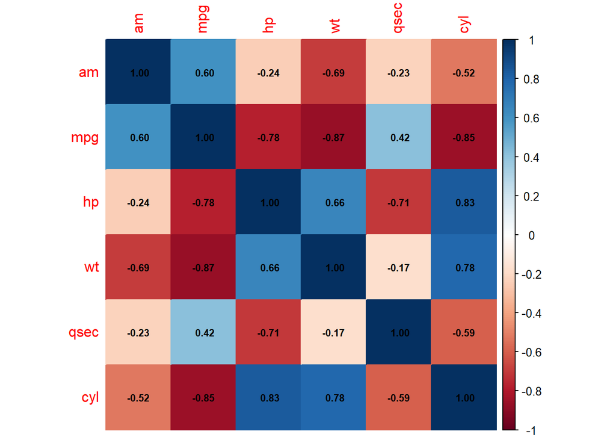

```r
vars <- c("am", "mpg", "hp", "wt", "qsec", "cyl")

data(mtcars)
sub_mtcars <- mtcars[, vars]

matriz_cor <- round(cor(sub_mtcars), 3)

# Visualización con la librería corrplot
library(corrplot)
corrplot(matriz_cor, method = "color", addCoef.col = "black", number.cex = 0.7)
```

```r
library(car)
vif_valores <- vif(model2)
print(vif_valores)
```

```
##       mpg        hp        wt      qsec       cyl
## 10.882447  8.863072  4.992337 21.583086 28.664523
```

- ¿Añadir más predictores mejora el AIC?

Sí, numéricamente disminuye de $16.77$ a $12.00$, lo cual parecería una mejora formal en AIC.

- ¿Son todos estos necesarios?

No, no todos son necesarios. Al agregar demasiados predictores correlacionados (`cyl` y `qsec`, con valores de VIF superiores a 20) en un conjunto de datos pequeño ($n=32$) hace que las estimaciones de los coeficientes se inflen de manera inestable y los errores estándar aumenten drásticamente (obteniendo p-values a $1.00$). Por lo tanto, no es conveniente mantener variables redundantes.

## Declaratoria de uso de IA durante el desarrollo del trabajo

Se utilizó IA:

1. Herramienta: Gemini
2. Uso realizado: Ayuda en el código a lo largo de la tarea y en la interpretación de variables (significado de estas).
3. Secciones donde se utilizó: Ayuda en el código en los incisos e) y g), así como también interpretación en las variables del dataset (mayormente en el inciso b).
4. Validación realizada por los estudiantes: Se verificó, corrió y depuró todo el script de R, así como también analizaron todos los resultados arrojados para validar que todo estuviera correcto y en orden.
5. Confirmo de que se revisó, verificó y que se asume la responsabilidad del contenido final entregado.